# Part I - Superstore Dataset Exploration

## Multivariate Exploration

> Earlier on we saw the relationship between sales and profit. I will encode the plot to know how category and region is distributed in the plot.

```python
# Category Markers
cat_markers = [
    ['Furniture', 'o'] ,
    ['Office Supplies', '^'],
    ['Technology', '*']
]
# Region Markers
reg_markers = [
    ['West', 's'],
    ['East', 'x'],
    ['Central', 'o'],
    ['South', 'v']
]

# FUNCTION MARKER
# Scatter plot function to create a relation ship with shape encoding.
def prft_sales_encoding(var,mark):
    lst = []
    for cat, marker in mark:
        store_cat = store_sub[store_sub[var] == cat]
        plt.scatter(data = store_cat, x = 'sales', y = 'profit',
                    marker = marker, s = 25, alpha = 0.4)
        plt.xlabel('sales ($)')
        plt.ylabel('profit ($)')
        plt.xscale('log')
        plt.yscale('symlog')
        plt.xticks([1, 10, 100, 1000, 10000],['1', '10', '100', '1k', '10k'])
        plt.yticks([-1000, -100, -10, -1, 0, 1, 10, 100, 1000],
                  ['-1k', '-100', '-10', '-1', '0', '1', '10', '100', '1000']);
        lst.append(cat)
    plt.legend(lst);
```

**Display category on sales profit relationship**

Using the function to plot Categories of sales and profit.

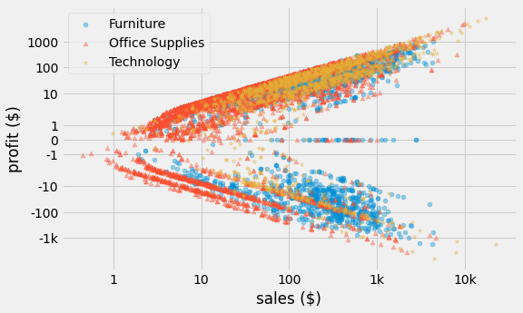

```python
# Encoding the category marker into the sales profit scatter plot
prft_sales_encoding('category',cat_markers)
```

We can clearly see now that products from the Furniture category are much in the loss part of profit. I cluster most in the sales region of \$100 to $1k. The Office Supplies category is clustered the most in the positive side of profit though not as high as the Technology category. Earlier on we saw that the highest sale made a loss, here we can see that the product belongs to the Technology category.

**Display region on sales profit relationship**

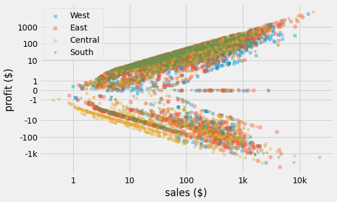

```python
# Encoding the region marker into the sales profit scatter plot
prft_sales_encoding('region',reg_markers)
```

Earlier on we saw that the highest sale made a loss, here we can see that the product was ordered by a customer in the south region. Later on we would know which segment the customer with this order belongs to.

**Note**: Earlier in the univariate section, scatter plot of sales and profit relationship, we saw that the highest sales made loss (negative profit). Here we can see that this sale was made from the Technology category in the South region.

How does discount relate to this plot? Let's see!

**Display discount as size on sales profit relationship**

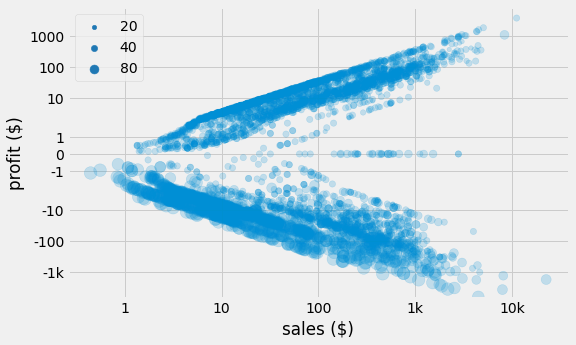

```python
# A plot of discount as size encoding on the sales profit scatter plot.
plt.scatter(data = store_sub, x = 'sales', y = 'profit',
                s = store_sub.discount*200, alpha = 0.2)
sizes =[20, 40, 80]
leg_obj = []
for s in sizes:
    leg_obj.append(plt.scatter([],[], s = s,
                               color=sb.color_palette('Paired')[1]));
plt.xlabel('sales ($)')
plt.ylabel('profit ($)')
plt.xscale('log')
plt.yscale('symlog')
plt.xticks([1, 10, 100, 1000, 10000],['1', '10', '100', '1k', '10k'])
plt.yticks([-1000, -100, -10, -1, 0, 1, 10, 100, 1000],
          ['-1k', '-100', '-10', '-1', '0', '1', '10', '100', '1000']);
plt.legend(leg_obj, sizes);
# plt.xlim(0,4000)
# plt.ylim(-2000, 500);
```

The plot shows that products that generate losses usually have high discounts. Maybe the high discount is actually the cause of this loss. Extra data would be needed if this should be investigated.

Headups, I am going to use barplot to show the average sales and profit across different category variables, then I will use heatmap to display the exact average.

Let's look at average sales made in each category of a region. First l will create a function for a similar purpose.

```python
# A function to create a bivariate barplot of two categorical variable and one numeric variable
def barplot(cat_var1, num_var, cat_var2):
    sb.barplot(data = store_sub, x = cat_var1, y = num_var,
             hue =cat_var2, errwidth = 0)
    plt.ylabel('avg. {} ($)'.format(num_var));
```

```python
# Creating a function to plot a heatmap of two categorical with average value of numeric variable displayed
# Note this function takes the data to plot from as an input.
def avg_num_cats(cat1, num, cat2, data):
    reg_cat = data.groupby([cat1, cat2])[num].mean()
    reg_cat = reg_cat.reset_index(name = '{}'.format(num))
    reg_cat = reg_cat.pivot(index = cat1, columns = cat2,
                           values = '{}'.format(num))
    sb.heatmap(reg_cat, annot = True, fmt = '.2f', cmap = 'viridis_r',
              cbar_kws={'label': 'avg. {} ($)'.format(num)})
    plt.title('Avg. {} of each {} in all {}'.format(num, cat2, cat1))
    plt.yticks(rotation=0);
```

**Average sales made from each category in each region**

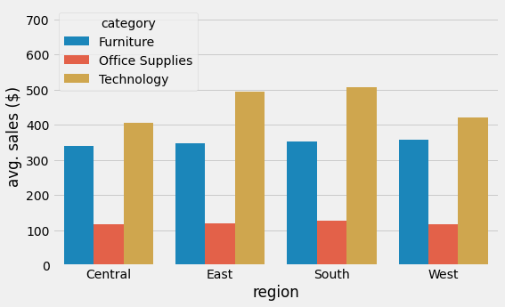

```python
# Plotting average sales of each category in each region.
barplot('region', 'sales', 'category')
```

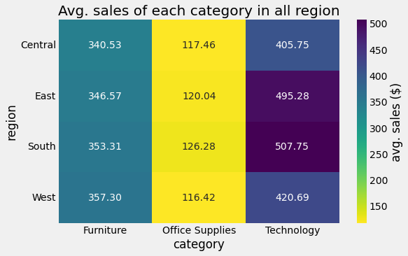

```python
# Displaying values of above plot using heatmap.
avg_num_cats('region', 'sales', 'category', store_sub)
```

I will plot for average profit next.

**Average profit made from each category in each region**

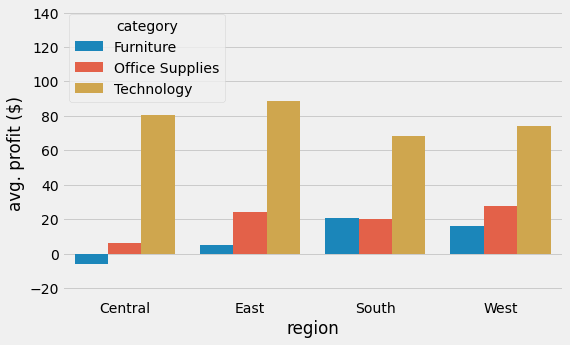

```python
# Plotting average profit of each category in each region.
barplot('region', 'profit', 'category')
```

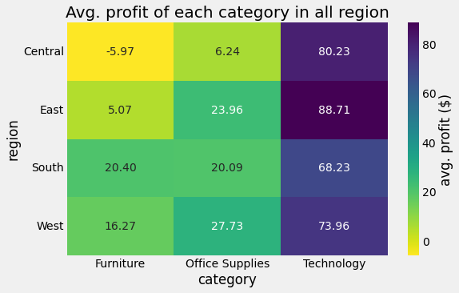

```python
# Displaying values of above plot using heatmap.
avg_num_cats('region', 'profit', 'category', store_sub)
```

In the previous barplot, Furniture was the second category that made much average sales. The plot above shows that Furniture is not generating profit despite high sales, it made no profit in the central region.

Below, I'm going to check the total profit made by each sub-category.

```python
# Heatmap plot function to display total of numeric variable across two categorical variable
def SubCatDetails(num_var):
    sub_cat = store_sub.groupby(['category', 'sub_category'])[num_var].sum()
    sub_cat = sub_cat.reset_index(name = 'total_{}'.format(num_var))
    name = 'total_{}'.format(num_var)
    sub_cat = sub_cat.query('{} != 0'.format(name))
    sub_cat = sub_cat.pivot(index = 'sub_category', columns = 'category',
                           values = name )
    sb.heatmap(sub_cat, cmap = 'viridis_r', annot = True, fmt = '.2f',
              cbar_kws={'label': 'Total {} ($)'.format(num_var)})
    plt.title('Total {} in each sub-category'.format(num_var));
```

**Total profit made from each sub-category in their category**

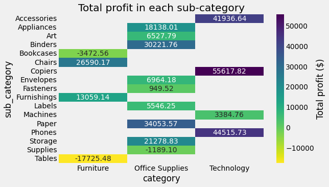

```python
# Plotting heatmap to display total profit made from each sub-category in each category
SubCatDetails('profit')
```

Surprisingly, the product loss is reflecting on Furniture (Bookcase and Tables) and Office Supplies (Supplies). Earlier we saw that technology was generating the highest profit and I dug further to see the top 5 states. Does this mean that there is no product loss in the Technology category? I doubt that, I will know by viewing its sub-category.

We already have the data of Technology category stored to the variable "tech" above.

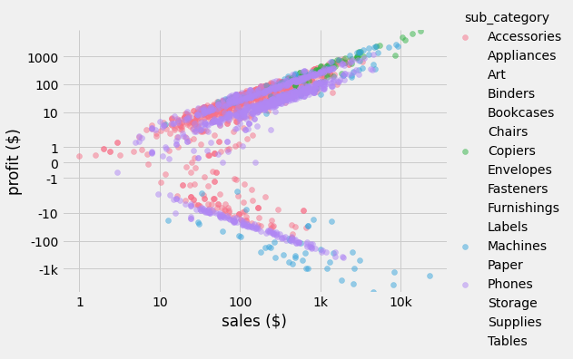

```python
# Plotting the tech data to display loss
g = sb.FacetGrid(data = tech, hue = 'sub_category', height = 5,
                aspect = 1.5)
g.map(plt.scatter, 'sales', 'profit', alpha = 0.5);
g.add_legend()
plt.xscale('log')
plt.yscale('symlog')
plt.xticks([1, 10, 100, 1000, 10000],['1', '10', '100', '1k', '10k'])
plt.yticks([-1000, -100, -10, -1, 0, 1, 10, 100, 1000],
          ['-1k', '-100', '-10', '-1', '0', '1', '10', '100', '1000']);
plt.xlabel('sales ($)')
plt.ylabel('profit ($)');
```

Now I am certain that there is product loss in the technology category and Machines sub-category has much loss.

I will now plot the total sales each sub-category made.

**Total sales made from each sub-category in their category**

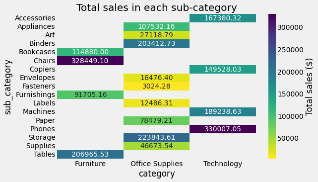

```python
# Plotting heatmap to display total sales made from each sub-category in each category
SubCatDetails('sales')
```

Lower sales are made in the sub-category of Office Supplies.

I will create a new column that says *profit* for positive profits and *loss* for negative profits.

**Note: I will be talking more about profit below because I am digging into the ten states with loss (negative profit). The data used below is "LossState" data which was created in the ending part of the Bivariate section, unless otherwise stated.**

```python
# Creating a column (income_status) that has "profit" for positve value in profit column and "loss" for negative value
cond = LossState.profit.astype(str).str.contains(r"-\d+")
LossState['income_status'] = np.where(cond,'loss', 'profit')
LossState.sample(5)
```

| row_id | order_date | ship_date | ship_mode | order_year | customer_name | segment | state | region | category | sub_category | sales | quantity | discount | profit | income_status |
| --- | --- | --- | --- | --- | --- | --- | --- | --- | --- | --- | --- | --- | --- | --- | --- |
| 3676 | 2017-11-06 | 2017-11-11 | Standard Class | 2017 | Maris LaWare | Consumer | Pennsylvania | East | Office Supplies | Paper | 47.952 | 3 | 0.2 | 16.1838 | profit |
| 971 | 2014-01-16 | 2014-01-18 | Second Class | 2014 | Delfina Latchford | Consumer | Pennsylvania | East | Furniture | Furnishings | 127.104 | 6 | 0.2 | 28.5984 | profit |
| 2742 | 2016-02-25 | 2016-02-27 | Second Class | 2016 | Bruce Degenhardt | Consumer | Ohio | East | Office Supplies | Envelopes | 46.720 | 5 | 0.2 | 17.5200 | profit |
| 2869 | 2016-11-10 | 2016-11-12 | Second Class | 2016 | Art Foster | Consumer | Ohio | East | Office Supplies | Storage | 38.976 | 3 | 0.2 | -2.4360 | loss |
| 6814 | 2017-09-14 | 2017-09-15 | First Class | 2017 | Pamela Stobb | Consumer | Pennsylvania | East | Furniture | Furnishings | 127.936 | 8 | 0.2 | 4.7976 | profit |

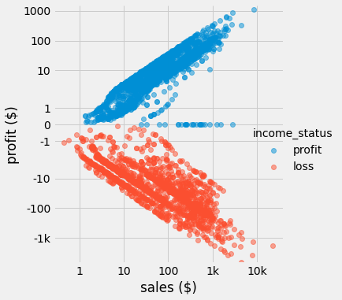

```python
# Encoding income status into sale profit scatter plot
g = sb.FacetGrid(data = LossState, hue = 'income_status',
                 hue_order = ['profit', 'loss'], height = 4, aspect = 2)
g.map(sb.regplot, 'sales', 'profit', fit_reg = False,
      scatter_kws = {'alpha':0.5});
g.add_legend()
g.fig.set_size_inches(6,6)
plt.xscale('log')
plt.yscale('symlog')
plt.xticks([1, 10, 100, 1000, 10000],['1', '10', '100', '1k', '10k'])
plt.yticks([-1000, -100, -10, -1, 0, 1, 10, 100, 1000],
          ['-1k', '-100', '-10', '-1', '0', '1', '10', '100', '1000'])
plt.xlabel('sales ($)')
plt.ylabel('profit ($)');
```

Let's see this plot for each category.

**Relationship between sales and profit for each category**

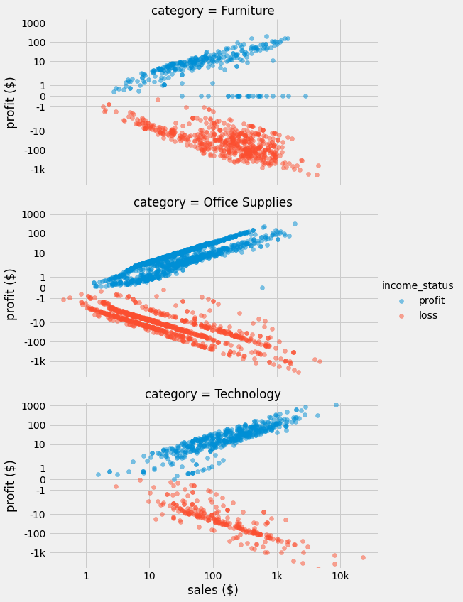

```python
# Plotting the for each category the sales profit scatter plot with income status color encoding
g = sb.FacetGrid(data = LossState, col = 'category', col_wrap = 1,
                 height = 4, hue = 'income_status', aspect = 2,
                hue_order = ['profit', 'loss'])
g.map(plt.scatter, 'sales', 'profit', alpha = 0.5)
g.add_legend()
g.set_axis_labels('sales ($)', 'profit ($)')
plt.xscale('log')
plt.yscale('symlog')
plt.xticks([1, 10, 100, 1000, 10000],['1', '10', '100', '1k', '10k'])
plt.yticks([-1000, -100, -10, -1, 0, 1, 10, 100, 1000],
          ['-1k', '-100', '-10', '-1', '0', '1', '10', '100', '1000']);
```

There is much clustering of loss in the Furniture category within the sale range of \$100 to $1k, and the frequency is much compared to that of Technology category.

**Relationship between sales and profit for each region**

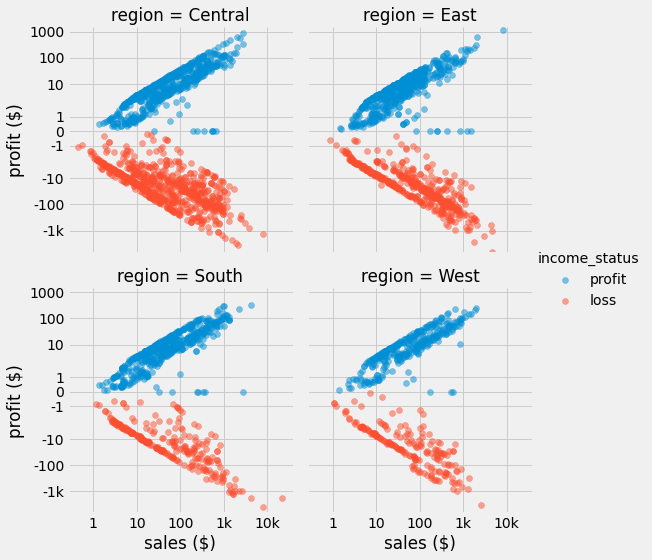

```python
# Plotting the for each region the sales profit scatter plot with income status color encoding
g = sb.FacetGrid(data = LossState, col = 'region', col_wrap = 2,
                 height = 4, hue = 'income_status', aspect = 1,
                hue_order = ['profit', 'loss'])
g.map(plt.scatter, 'sales', 'profit', alpha = 0.5)
g.add_legend()
g.set_axis_labels('sales ($)', 'profit ($)')
plt.xscale('log')
plt.yscale('symlog')
plt.xticks([1, 10, 100, 1000, 10000],['1', '10', '100', '1k', '10k'])
plt.yticks([-1000, -100, -10, -1, 0, 1, 10, 100, 1000],
          ['-1k', '-100', '-10', '-1', '0', '1', '10', '100', '1000']);
```

Among the ten states, there is much loss in the central region as shown on the plot. There is much loss clustered in the central region compared to others. I think we should find how the state plays a part in this loss.

**Checking State contribution to loss in central region**

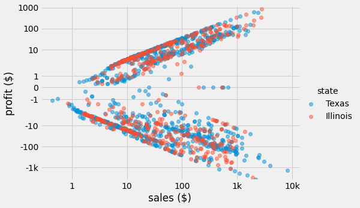

```python
# Filtering for Central region
LossState_central = LossState.query('region == "Central"')
# Plot of sales profit relationship of central region only
g = sb.FacetGrid(data = LossState_central, hue = 'state', height = 5,
                aspect = 1.5)
g.map(sb.regplot, 'sales', 'profit', fit_reg = False,
      scatter_kws = {'alpha':0.5});
g.add_legend()
plt.xscale('log')
plt.yscale('symlog')
plt.xticks([1, 10, 100, 1000, 10000],['1', '10', '100', '1k', '10k'])
plt.yticks([-1000, -100, -10, -1, 0, 1, 10, 100, 1000],
          ['-1k', '-100', '-10', '-1', '0', '1', '10', '100', '1000'])
plt.xlabel('sales ($)')
plt.ylabel('profit ($)');
```

It turns out that there are only two states in the central region, Texas and Illinois. Let's see this sales profit relationship for all States.

**Relationship between sales and profit for each state with loss**

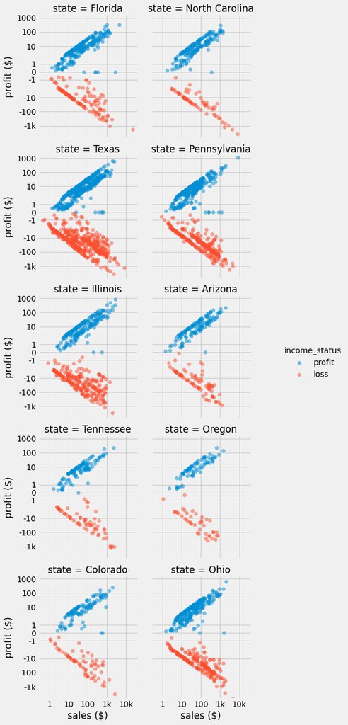

```python
# Scatter plot of sales profit relationship in each states showing the income status with color encoding
g = sb.FacetGrid(data = LossState, col = 'state', col_wrap = 2,
                 height = 4, hue = 'income_status', aspect = 0.65,
                hue_order = ['profit', 'loss'])
g.map(plt.scatter, 'sales', 'profit', alpha = 0.5)
g.add_legend()
g.set_axis_labels('sales ($)', 'profit ($)')
g.fig.set_size_inches(10,18)
plt.xscale('log')
plt.yscale('symlog')
plt.xticks([1, 10, 100, 1000, 10000],['1', '10', '100', '1k', '10k'])
plt.yticks([-1000, -100, -10, -1, 0, 1, 10, 100, 1000],
          ['-1k', '-100', '-10', '-1', '0', '1', '10', '100', '1000']);
```

Tennessee and Oregon seem to have lower frequency of loss compared to others.

```python
# Category Markers
cat_markers = [
    ['Furniture', 'o'] ,
    ['Office Supplies', '^'],
    ['Technology', '*']
]
# Region Markers
reg_markers = [
    ['West', 's'],
    ['East', 'x'],
    ['Central', 'o'],
    ['South', 'v']
]
# Facet Grid with scatter plot function to create a sales profit relationshi
# for each category, showing each region
def prft_sales_encoding(var,mark):
    lst = []
    for cat, marker in mark:
        store_cat = LossState[LossState[var] == cat]
        g = sb.FacetGrid(data = store_cat, col = 'region',hue = var, col_wrap = 2,
                 height = 4, aspect = 0.65,hue_order = ['Furniture','Office Supplies', 'Technology'])
        g.map(plt.scatter, 'sales', 'profit', alpha = 0.5,
              marker = marker,)
        g.fig.set_size_inches(10,12)
        g.add_legend()
        g.set_axis_labels('sales ($)', 'profit ($)')
        plt.xscale('log')
        plt.yscale('symlog')
        plt.xticks([1, 10, 100, 1000, 10000],['1', '10', '100', '1k', '10k'])
        plt.yticks([-1000, -100, -10, -1, 0, 1, 10, 100, 1000],
                  ['-1k', '-100', '-10', '-1', '0', '1', '10', '100', '1000']);
```

**For each category, the relationship Between sales and profit in each region**

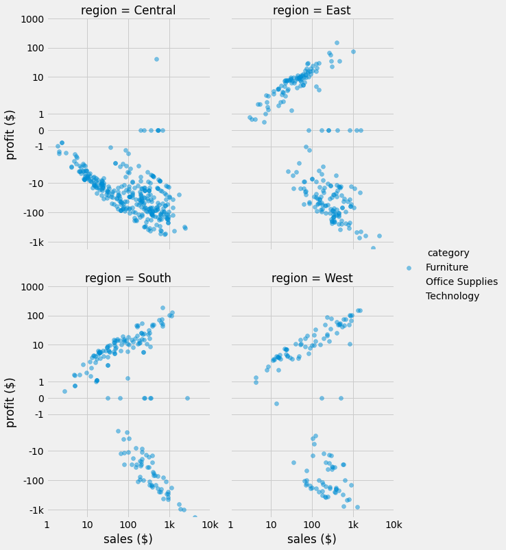

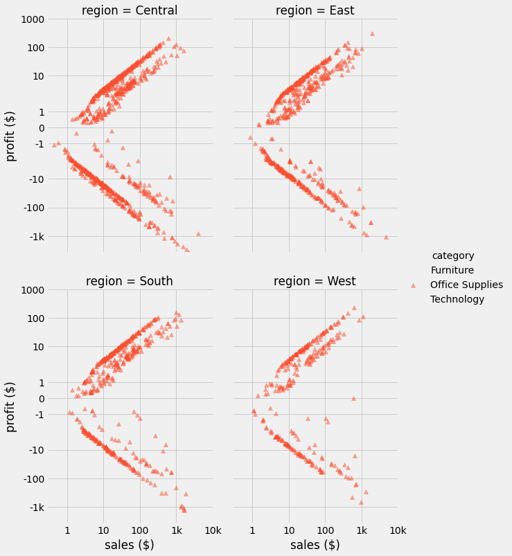

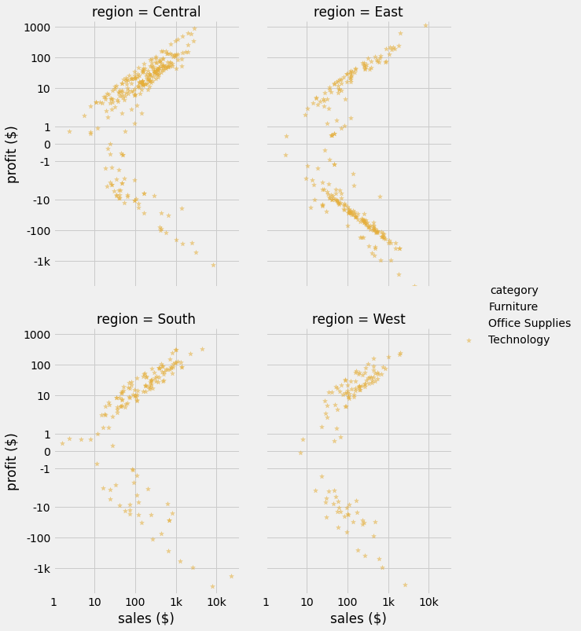

```python
prft_sales_encoding('category',cat_markers)
```

For the Furniture category, the central region has merely a single profit above $1. There is also a large cluster of loss in the central region. For Office Supplies there is a strong positive and negative relationship in all regions. While in Technology category, The south and west has a weak negative relationship.

Though I am looking at profit, let's first see average sales made from each segment in each region.

**Average sales made from each segment for all category across each regions**

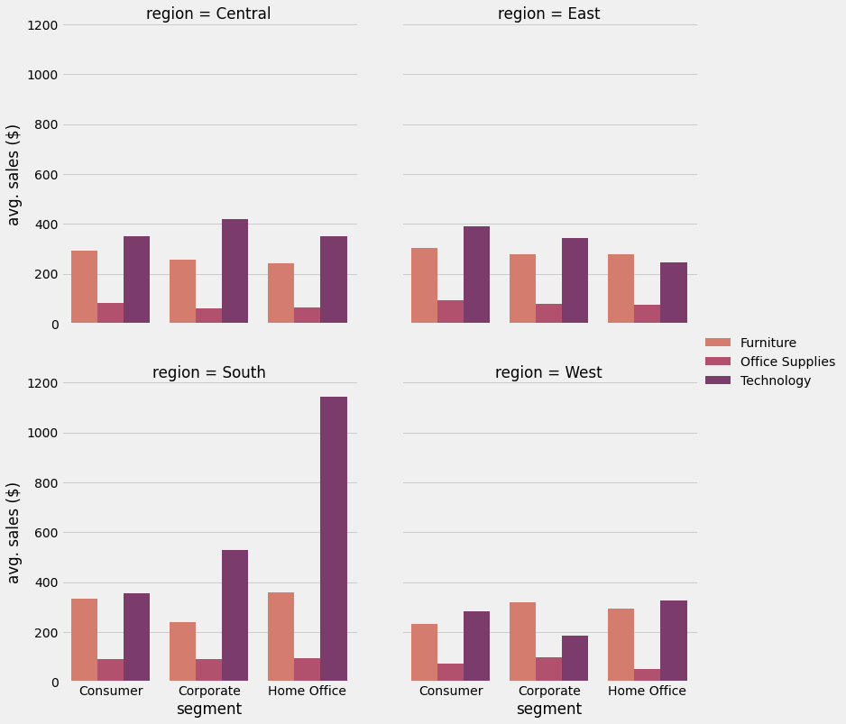

```python
# Barplot showing average sales made from each category across all segment in each region.
g = sb.FacetGrid(data = LossState, col = 'region', col_wrap = 2,
                 height = 4, aspect = 0.9)
g.map(sb.barplot, 'segment', 'sales', 'category',
      palette = 'flare', errwidth = 0);
g.fig.set_size_inches(12,12)
g.add_legend()
g.set_axis_labels('segment', 'avg. sales ($)')
plt.ylim(0,1200);
```

Let's now look at profit made in each segment for each region.

**Average profit made from each segment for all category across each regions**

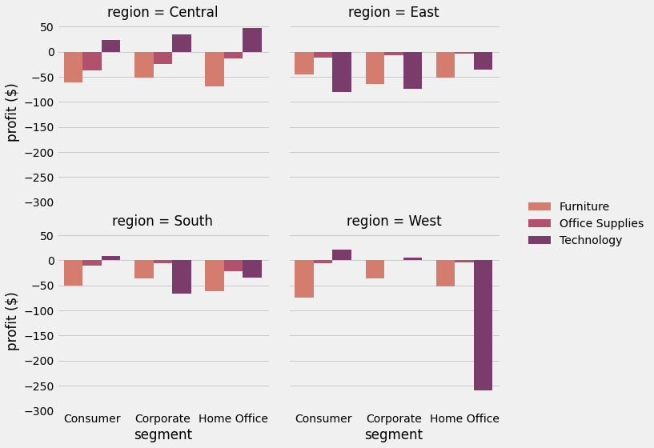

```python
# Barplot showing average profit made from each category across all segment in each region.
g = sb.FacetGrid(data = LossState, col = 'region', col_wrap = 2,
                 height = 4, aspect = 1)
g.map(sb.barplot, 'segment', 'profit', 'category',
      palette = 'flare', errwidth = 0);
g.add_legend()
g.fig.set_size_inches(12,8)
g.set_axis_labels('segment', 'profit ($)')
plt.ylim(-300,60);
```

There is high loss from the technology category and it is from the Home Office segment in the west. In the east, none of the categories of product made any profit in all segments. It looks like the Office Supplies category in the Corporate segment of the West region made neither profit nor loss, but remember we are looking at the average profit here.

Let's see the average sales made in each state

**Average sales from each category across all state with loss**

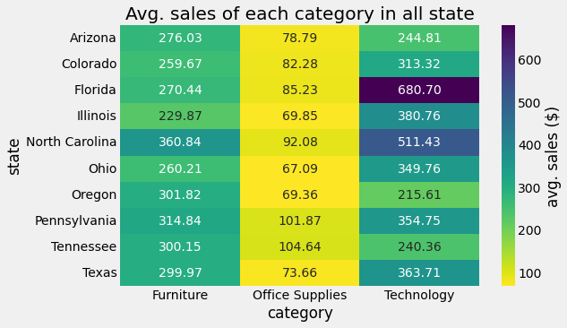

```python
# Using the function created earlier that take in data and display the average of a
#numeric value between two categorical variable.

# Heatmap showing average sales of LossState data in each category across all state
avg_num_cats('state', 'sales', 'category', LossState)
```

**Average profit from each category across all state with loss**

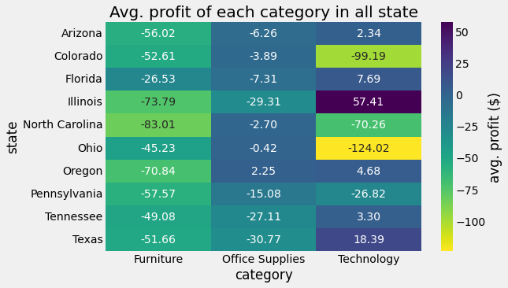

```python
# Heatmap showing average profit of LossState data in each category across all state
avg_num_cats('state', 'profit', 'category', LossState)
```

### Talk about some of the relationships you observed in this part of the investigation. Were there features that strengthened each other in terms of looking at your feature(s) of interest?

> I checked the average sales made in each region from each category. The heat map showed that Office supplies have low average sales (below 130 dollars) in all regions compared to the other category that has high average sales (over 300 dollars) in all regions.

### Were there any interesting or surprising interactions between features?

> A heatmap was plotted to show the total profit made from each subcategory, and it showed that Copiers generated the highest profit (over \$55,000) and it belonged to the technology category. On the other hand Tables from furniture category was making loss (up to -\$17,000)

## Conclusions

> Sales has a unimodal distribution when plotted with a logarithmic scale. It has both positive and negative correlation with profit, this is as a result of some product generating loss (negative profit).

> The Office Supplies category is the most ordered product with over 6,000 count, mostly bought in the west. Sadly, this high count did not contribute much to the sales generated. A bar chart was plotted and it depicts that Office Supplies generate the least average sales (below \$150) compare to others that has over $300

> Products ordered to the South are the least compared to other regions. Office Supplies product is the most sold product in this region (count of 995) with Technology as the least (count of 293).

> South generates the highest average sales and Technology which was the least ordered product in this region made the highest sales , approximately $508

> When considering the data of the 10 states with loss (negative profit) only, a heatmap depicts that Office Supplies category generates the least average sales across all states. Another heat map depicts that the majority of the category had loss across each state which is no surprise since we are looking at states with loss. But the loss of Ohio stood out because it was the highest, a loss of approximately -$124